# QTM 151 - Quiz 2

## Try to submit as an HTML file

Print your Emory code below

```python
# Write your answer here
print(2610436)
```

```
2610436
```

This quiz is open book

- You can use the lecture notes and Google
- You will get partial credit for attempting the questions
- To get full credit, the code should run as intended
- You should NOT communicate with other students

Print the following message:

"I will abide by Emory's code of conduct"

**By printing the message, you acknowledge that you will abide by Emory's code of conduct.**

```python
# Write your answer here:
print("I will abide by Emory's code of conduct")
```

```
I will abide by Emory's code of conduct
```

Import the libraries "numpy", "matplotlib.pyplot", and "pandas"

```python
# Write your answer here

import pandas as pd
import numpy as np
import matplotlib.pyplot as plt
```

Import the dataset "data_quiz/fifa23_players_basic.csv"

- It's a dataset on professional soccer players
- Rows correspond to players (18,539)
- Columns contain attributes of players (32)
- Try to view the dataset before starting

```python
# Write your own code
Dataset=pd.read_csv("data_quiz/fifa23_players_basic.csv")
```

(a) Create a function and apply it to a column

Step 1:

- Define a function with a parameter "overall"
- If "overall < 85", status = "Regular Player"
- If "age_player >= 85", status = "Top Player"
- The function returns "status"

Step 2:

- Extract the column "Overall" in the dataset  
  (be carefeful to write the "O" capitalized)
- Create a new variable called "top_players"  
  to assign each player to the correct status

HINT: Use the ".apply()" function

```python
# Write your own code
def fn_playerstatus(overall):
    if (overall<85):
        status="Regular Player"
    if (overall>=85):
        status="Top Player"
    return status

Dataset["top_players"]=Dataset["Overall"].apply(fn_playerstatus)
```

(b) Use queries + global variables

- Compute the mean of the column "Wage(in Euro)"  
  and store it as a variable
- Subset the players whose value is above the mean value  
  using ".query()"

HINT: Remember that there is a special syntax for  
when the column names have spaces (see Lecture 9)  
Reference the column as `` `Wage(in Euro)` `` inside .query()

```python
# Write your own code
wage_mean=Dataset["Wage(in Euro)"].mean()
above_mean_wage_players=Dataset.query('`Wage(in Euro)`>@wage_mean')
```

(c) Use sorting + ".iloc[]"

- Use ".sort_values()" to order the "Age" column  
  from youngest to oldest
- Get a subset with the 5 youngest players
- Print their age

```python
# Write your own code
Players_sorted=Dataset.sort_values(by = "Age", ascending=True)
Youngest_players=Players_sorted.iloc[0:5]
print(Youngest_players["Age"])
```

```
17956    16
18014    16
16084    16
11481    16
17591    16
Name: Age, dtype: int64
```

(d) Create a function with four inputs $f(y,x,b0,b1)$

$\qquad e2 = (y - b_0 - b_1 * x)^2$

- The function should return the mean of e2
- This is the mean-square error (mse)
- Call the function "fn_mse"
- Let $y$ be the column "Potential"
- Let $x$ be the column "Age"
- Does  
  $\qquad (b_0 = 80, b_1 = 0.4)$ or  
  $\qquad (b_0 = 80, b_1 =-0.3)$ or  
  $\qquad (b_0 = 80, b_1 = -0.5)$  
  produce the lowest value of mse?
- Print your results

```python
# Write your own code
def fn_mse(y,x,b0,b1):
    e2=(y-b0-b1*x)**2
    return e2.mean()

y=Dataset["Potential"]
x=Dataset["Age"]

print(fn_mse(y,x,80,0.4))
print(fn_mse(y,x,80,-0.3))
print(fn_mse(y,x,80,-0.5))
print("b0 = 80, b1 =-0.3 produces the lowest value of mse")
```

```
412.1016840174767
37.72189870003776
49.43713253142025
b0 = 80, b1 =-0.3 produces the lowest value of mse
```

(e) Split a dataset into subsets

- Create `list_status = [0,1]`
- Create `list_prob = [0.5, 0.5]`
- Create a new variable $n$ with the number of rows of the dataset
- Define a random seed that equals 42
- Use

```
np.random.choice(list_status,
                     size = n,
                     p = list_prob)
```

$\qquad$ to create a new column called "status"  
$\qquad$ which randomly assigns each row to "0" or "1"  
$\qquad$ with equal probability

- Use .query() to subset all observations with status == 0.  
  store it in a new dataset called "data0"
- Use .query() to subset all observations with status == 1.  
  store it in a new dataset called "data1"

```python
# Write your own code
list_status = [0,1]
list_prob = [0.5, 0.5]
n=len(Dataset)
np.random.seed(42)
Dataset["status"] = np.random.choice(list_status, size = n, p = list_prob)
data0=Dataset.query('status==0')
data1=Dataset.query('status==1')
```

(f) Create two overlapping histogram plots

- This question requires the two datasets you created in (e)
- Display the distribution of "Age" for "data0" and "data1"
- Use the "alpha" option to make the graphs semitransparent
- You will need to add a legend, label the axes, and the title

Note: The goal of this question is to illustrate that random  
assignment produces very similar distributions between two groups

- Provide a short interpretation of the graph using the information from the Note

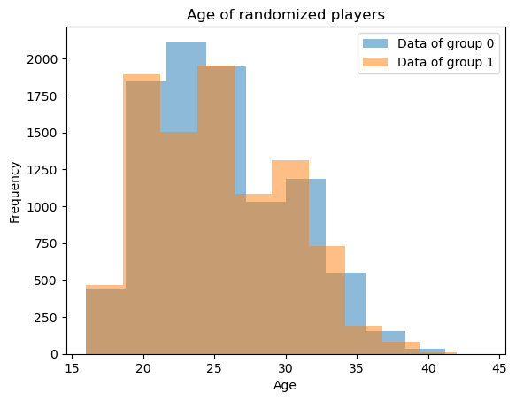

```
It can be seen from the graph that the distribution of age of the two groups, which are assigned randomly, are similar. This supports the idea that random assignment produces very similar distribution between two groups. Therefore, randomization is a good approach for scientific research.
```

```python
# Write your own code
plt.hist(x = data0["Age"], alpha=0.5)
plt.hist(x = data1["Age"], alpha=0.5)

plt.xlabel("Age")
plt.ylabel("Frequency")
plt.legend(labels = ["Data of group 0", "Data of group 1"])
plt.title('Age of randomized players')
plt.show()

print("It can be seen from the graph that the distribution of age of the two groups, which are assigned randomly, are similar. This supports the idea that random assignment produces very similar distribution between two groups. Therefore, randomization is a good approach for scientific research. ")
```